# Анализ вакансий аналитиков на hh.ru

### Определим какие навыки спрашивают чаще hard или soft?

```python
# Функция для подсчета количества вакансий с указанными навыками
def count_skill_mentions(df, skill_column):
    # Фильтруем "не указаны" и подсчитываем строки, где есть навыки
    return df[df[skill_column] != 'не указаны'][skill_column].count()

# Подсчитываем количество вакансий с hard и soft skills
hard_skill_mentions = count_skill_mentions(df_filtered, 'hard_skills')
soft_skill_mentions = count_skill_mentions(df_filtered, 'soft_skills')

# Рассчитываем отношение soft к hard скиллам
if hard_skill_mentions > 0:
    skill_ratio = soft_skill_mentions / hard_skill_mentions
else:
    skill_ratio = 0  # если нет вакансий с hard skills, то отношение 0

# Выводим результат
print(f"Количество вакансий с hard skills: {hard_skill_mentions}")
print(f"Количество вакансий с soft skills: {soft_skill_mentions}")
print(f"Отношение soft skills к hard skills: {skill_ratio:.2f}")
```

```
Количество вакансий с hard skills: 5196
Количество вакансий с soft skills: 3006
Отношение soft skills к hard skills: 0.58
```

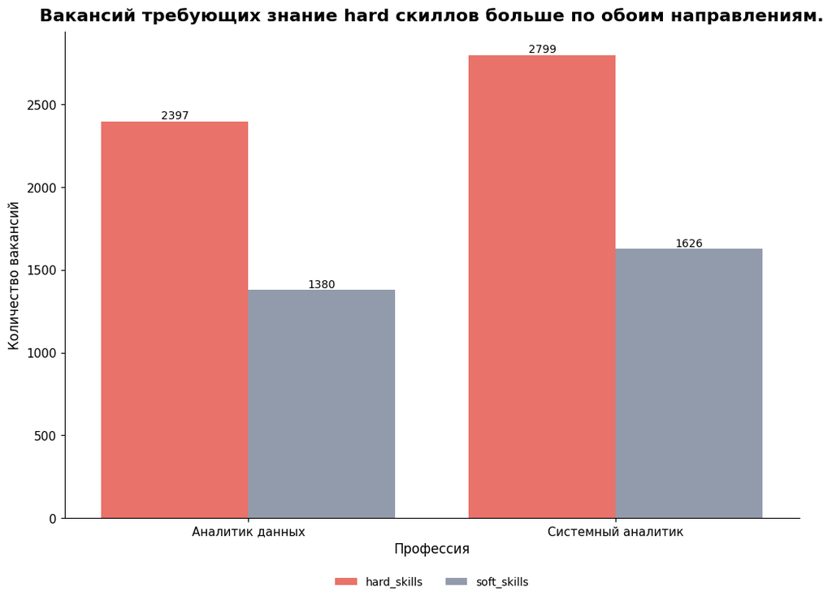

```python
# Преобразуем данные для построения графика
skill_data_by_profession = df_filtered.groupby(['profession']).agg({
    'hard_skills': lambda x: x[x != 'не указаны'].count(),
    'soft_skills': lambda x: x[x != 'не указаны'].count()
}).reset_index()

# Преобразуем данные в длинный формат для seaborn
skill_data_long = pd.melt(skill_data_by_profession,
                          id_vars=['profession'],
                          value_vars=['hard_skills', 'soft_skills'],
                          var_name='skill_type',
                          value_name='Count')

# Настройки графика
plt.figure(figsize=(12, 8))

# Функция для построения графика с форматированием
def plot_distribution(data, title, ax, hue='skill_type', add_legend=True, legend_title=''):
    sns.barplot(
        data=data,
        x='profession',
        y='Count',
        hue=hue,
        palette=custom_palette,  # Использование custom_palette
        ax=ax
    )
    # Добавляем текст с количеством над столбцами
    for p in ax.patches:
        height = p.get_height()
        if height > 0:
            ax.text(
                p.get_x() + p.get_width() / 2,
                height,
                f'{height:.0f}',
                ha='center',
                va='bottom',
                fontsize=10
            )

    # Настройки графика
    ax.set_title(title, fontsize=16, fontweight='bold', pad=10)
    ax.set_xlabel('Профессия', fontsize=12)
    ax.set_ylabel('Количество вакансий', fontsize=12)
    ax.tick_params(axis='x',  labelsize=11)
    ax.tick_params(axis='y', labelsize=11)
    sns.despine()

    # Добавляем легенду под график
    if add_legend:
        ax.legend(
            title=legend_title,
            fontsize=10,
            loc='upper center',
            bbox_to_anchor=(0.5, -0.1),
            ncol=4,
            frameon=False
        )

# Строим график
plot_distribution(skill_data_long,
                  'Вакансий требующих знание hard скиллов больше по обоим направлениям.',
                  plt.gca(),
                  add_legend=True)

# Отобразим график
plt.show()
```

Вакансий требующих знание hard навыков больше, чем вакансий требующих soft по обоим направлениям.

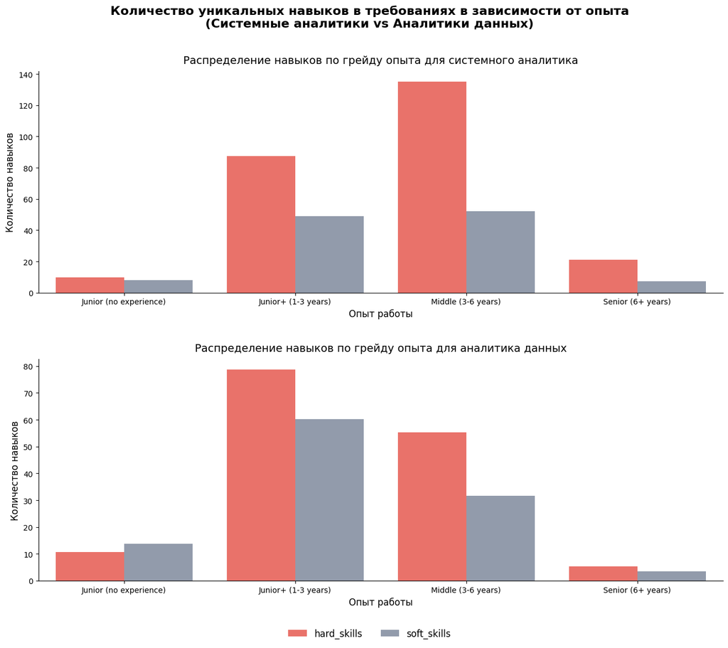

```python
# Функция для подсчета навыков с использованием explode()
def count_skills_by_experience(df, skill_column):
    # Фильтруем "не указаны"
    df_filtered = df[df[skill_column] != 'не указаны'].copy()

    # Разделяем строку навыков на список
    df_filtered['skills'] = df_filtered[skill_column].str.split(',')

    # Используем explode для развертывания списка в строки
    df_skills = df_filtered.explode('skills')

    # Убираем пробелы в названиях навыков
    df_skills['skills'] = df_skills['skills'].str.strip()

    # Группируем по опыту и навыкам, подсчитываем количество
    skill_counts = df_skills.groupby(['experience', 'skills']).size().reset_index(name='count')

    return skill_counts

# Для СА
sa_hard_skills_by_exp = count_skills_by_experience(sa_data, 'hard_skills')
sa_soft_skills_by_exp = count_skills_by_experience(sa_data, 'soft_skills')

# Для ДА
da_hard_skills_by_exp = count_skills_by_experience(da_data, 'hard_skills')
da_soft_skills_by_exp = count_skills_by_experience(da_data, 'soft_skills')

# Добавляем информацию о типе навыков для СА
sa_hard_skills_by_exp['skill_type'] = 'hard_skills'
sa_soft_skills_by_exp['skill_type'] = 'soft_skills'

# Добавляем информацию о типе навыков для ДА
da_hard_skills_by_exp['skill_type'] = 'hard_skills'
da_soft_skills_by_exp['skill_type'] = 'soft_skills'

# Объединяем данные для СА и ДА
sa_all_skills_by_exp = pd.concat([sa_hard_skills_by_exp, sa_soft_skills_by_exp])
da_all_skills_by_exp = pd.concat([da_hard_skills_by_exp, da_soft_skills_by_exp])

# Создаем фигуру с двумя подграфиками (один под другим)
fig, axes = plt.subplots(2, 1, figsize=(16, 12))

# График для СА
sns.barplot(
    data=sa_all_skills_by_exp,
    x='experience',
    y='count',
    hue='skill_type',
    palette=custom_palette,
    hue_order=['hard_skills', 'soft_skills'],
    ci=None,
    ax=axes[0]
)

# Настройка графика для СА
axes[0].set_title('Распределение навыков по грейду опыта для системного аналитика', fontsize=14, pad=10)
axes[0].set_xlabel('Опыт работы', fontsize=12)
axes[0].set_ylabel('Количество навыков', fontsize=12)
axes[0].tick_params(axis='y', labelsize=10)
axes[0].legend().set_visible(False)  # Убираем легенду сверху графика
sns.despine(ax=axes[0])

# График для ДА
sns.barplot(
    data=da_all_skills_by_exp,
    x='experience',
    y='count',
    hue='skill_type',
    palette=custom_palette,
    hue_order=['hard_skills', 'soft_skills'],
    ci=None,
    ax=axes[1]
)

# Настройка графика для ДА
axes[1].set_title('Распределение навыков по грейду опыта для аналитика данных', fontsize=14, pad=10)
axes[1].set_xlabel('Опыт работы', fontsize=12)
axes[1].set_ylabel('Количество навыков', fontsize=12)
axes[1].tick_params(axis='y', labelsize=10)
axes[1].legend().set_visible(False)  # Убираем легенду сверху графика
sns.despine(ax=axes[1])

# Добавление общей легенды
handles, labels = axes[0].get_legend_handles_labels()
fig.legend(
    handles, labels,
    title='',
    fontsize=12,
    loc='upper center',
    bbox_to_anchor=(0.5, 0.05),  # Позиция легенды под графиками
    ncol=4,
    frameon=False
)
# Общий заголовок
fig.suptitle('Количество уникальных навыков в требованиях в зависимости от опыта\n(Системные аналитики vs Аналитики данных)',
             fontsize=16, fontweight='bold')

#Изменяем расстояние между графиками
plt.subplots_adjust(hspace=0.3)  # Увеличиваем пространство между графиками
# Отображение графика
plt.show()
```

Наибольшее количество различных навыков для аналитиков данных требуют на Junior+ уровне, тогда как для системных аналитиков на middle. Для Junior специалистов требования по количеству различных навыков СОФТ и ХАРД примерно на одном уровне.

### Какие навыки самые важные?

```python
# Зададим функцию для расчета количества навыков и формирования таблиц с ТОП навыками.
def format_top_skills_with_counts(data, skill_column):
    """
    Создаёт таблицу навыков и их количества по уровням опыта.
    В результате каждый уровень опыта представлен колонками: skill, count.
    """
    # Фильтруем данные: оставляем только те строки, где указаны навыки
    data_filtered = data[data[skill_column] != 'не указаны'].copy()
    data_filtered['skills'] = data_filtered[skill_column].str.split(',')  # Разделяем навыки
    data_exploded = data_filtered.explode('skills')  # Разворачиваем список навыков
    data_exploded['skills'] = data_exploded['skills'].str.strip()  # Убираем лишние пробелы

    # Группировка по уровню опыта и навыку
    skill_counts = (
        data_exploded.groupby(['experience', 'skills'])
        .size()
        .reset_index(name='count')
        .sort_values(by=['experience', 'count'], ascending=[True, False])
    )

    # Выбираем топ-10 навыков для каждого уровня опыта
    top_skills = (
        skill_counts.groupby('experience')
        .apply(lambda x: x.nlargest(15, 'count'))
        .reset_index(drop=True)
    )

    # Создаём таблицу с колонками "skill, count" для каждого уровня опыта
    result = pd.DataFrame()
    for experience_level in top_skills['experience'].unique():
        subset = top_skills[top_skills['experience'] == experience_level]
        subset = subset[['skills', 'count']].reset_index(drop=True)
        subset.columns = [experience_level, f"{experience_level}_count"]
        result = pd.concat([result, subset], axis=1)  # Объединяем по колонкам

    # Переименуем колонки в нужный формат
    rename_mapping = {
        "Junior (no experience)": "Junior skill name",
        "Junior (no experience)_count": "Junior count",
        "Junior+ (1-3 years)": "Junior+ skill name",
        "Junior+ (1-3 years)_count": "Junior+ count",
        "Middle (3-6 years)": "Middle skill name",
        "Middle (3-6 years)_count": "Middle count",
        "Senior (6+ years)": "Senior skill name",
        "Senior (6+ years)_count": "Senior count"
    }

    # Применяем переименование
    result.columns = [
        rename_mapping.get(col, col) for col in result.columns
    ]

    return result


# Создаём таблицы для каждой комбинации профессии и типа навыков
sa_hard_skills_table = format_top_skills_with_counts(sa_data, 'hard_skills')
sa_soft_skills_table = format_top_skills_with_counts(sa_data, 'soft_skills')
da_hard_skills_table = format_top_skills_with_counts(da_data, 'hard_skills')
da_soft_skills_table = format_top_skills_with_counts(da_data, 'soft_skills')
```

```python
# Зададим функцию для стилизации итоговых таблиц.
def style_table_with_bars(df, title, color='#4A90E2', column_width='200px', bar_color='#4A90E2'):
    """
    Форматирует таблицу и добавляет стили, включая визуальные бары для числовых значений.
    """
    # Сбросить индекс и сохранить таблицу для отображения
    df = df.reset_index(drop=True)

    # Преобразуем столбцы с количеством в числовой тип
    numeric_columns = [col for col in df.columns if 'count' in col]
    df[numeric_columns] = df[numeric_columns].apply(pd.to_numeric, errors='coerce')

    # Настроить стиль
    styled_table = df.style.set_properties(
        **{
            'font-size': '10pt',        # Размер шрифта
            'font-family': 'Arial',     # Шрифт
            'width': column_width       # Ширина столбцов
        }
    ).set_caption(title).set_table_styles(
        [
            # Стили для заголовка таблицы
            {
                'selector': 'caption',
                'props': [
                    ('text-align', 'center'),        # Центрируем заголовок
                    ('font-size', '12pt'),           # Размер шрифта заголовка
                    ('font-weight', 'bold'),         # Жирный шрифт заголовка
                    ('font-family', 'Arial'),        # Шрифт заголовка
                    ('color', 'white'),              # Цвет шрифта заголовка
                    ('background-color', color),     # Цвет фона заголовка
                    ('padding', '6px')              # Отступы вокруг заголовка
                ]
            },
            # Стили для заголовков столбцов
            {
                'selector': 'th',
                'props': [
                    ('font-size', '10pt'),            # Размер шрифта для заголовков столбцов
                    ('font-weight', 'bold'),          # Толщина шрифта для заголовков
                    ('font-family', 'Arial'),         # Шрифт заголовков
                    ('border', 'none'),              # Убираем границу для столбцов
                    ('padding', '8px'),              # Отступы вокруг текста в заголовках столбцов
                    ('width', column_width)          # Устанавливаем фиксированную ширину столбцов
                ]
            },
            # Стили для строк данных
            {
                'selector': 'td',
                'props': [
                    ('padding', '8px 4px'),         # Увеличиваем отступ между строками
                    ('border', 'none'),            # Убираем границу для ячеек данных
                    ('width', column_width)        # Устанавливаем фиксированную ширину столбцов
                ]
            }
        ]
    )

    # Применяем выравнивание для нечетных и четных столбцов
    for i, col in enumerate(df.columns):
        if i % 2 != 0:
            styled_table = styled_table.set_properties(subset=[col], **{'text-align': 'left'})
        else:
            styled_table = styled_table.set_properties(subset=[col], **{'text-align': 'right'})

    # Добавляем бары в числовые колонки
    styled_table = styled_table.bar(
        subset=numeric_columns,         # Применяем только к столбцам с количеством
        color=bar_color,                # Цвет полос
        align='mid'                     # Полосы начинаются с нуля
    )

    return styled_table

# Пример использования функции:
da_hard_styled = style_table_with_bars(da_hard_skills_table,
                                       title="Топ хард скиллы для аналитика данных",
                                       color=da_color,
                                       bar_color=da_color)
da_soft_styled = style_table_with_bars(da_soft_skills_table,
                                       title="Топ софт скиллы для аналитика данных",
                                       color=da_color,
                                       bar_color=da_color)

# Применим функцию к данным по ДА
display(da_hard_styled)
display(da_soft_styled)
```

Топ хард скиллы для аналитика данных

|  | Junior skill name | Junior count | Junior+ skill name | Junior+ count | Middle skill name | Middle count | Senior skill name | Senior count |
| --- | --- | --- | --- | --- | --- | --- | --- | --- |
| 0 | sql | 104 | sql | 1132 | sql | 726 | sql | 54 |
| 1 | excel | 97 | python | 830 | python | 553 | python | 44 |
| 2 | python | 75 | excel | 579 | power bi | 248 | etl | 20 |
| 3 | power bi | 32 | power bi | 430 | excel | 205 | clickhouse | 14 |
| 4 | pandas | 24 | tableau | 209 | tableau | 182 | power bi | 14 |
| 5 | numpy | 13 | pandas | 206 | clickhouse | 166 | tableau | 12 |
| 6 | etl | 11 | hadoop | 170 | etl | 149 | excel | 11 |
| 7 | power query | 11 | etl | 165 | pandas | 144 | git | 11 |
| 8 | clickhouse | 10 | clickhouse | 158 | проектирование | 132 | pandas | 9 |
| 9 | hadoop | 10 | numpy | 156 | ml модели | 118 | superset | 9 |
| 10 | разработка технических заданий | 10 | spark | 142 | superset | 115 | ab тесты | 8 |
| 11 | google sheets | 9 | проектирование | 131 | numpy | 111 | проектирование | 8 |
| 12 | проектирование | 9 | superset | 130 | hadoop | 102 | big data | 7 |
| 13 | greenplum | 8 | разработка технических заданий | 126 | greenplum | 95 | greenplum | 7 |
| 14 | jira | 8 | greenplum | 121 | agile | 82 | ml модели | 7 |

Топ софт скиллы для аналитика данных

|  | Junior skill name | Junior count | Junior+ skill name | Junior+ count | Middle skill name | Middle count | Senior skill name | Senior count |
| --- | --- | --- | --- | --- | --- | --- | --- | --- |
| 0 | аналитическое мышление | 43 | аналитическое мышление | 264 | коммуникабельность | 119 | коммуникабельность | 9.000000 |
| 1 | коммуникабельность | 35 | коммуникабельность | 194 | ответственность | 98 | английский | 7.000000 |
| 2 | ответственность | 30 | ответственность | 163 | английский | 94 | проактивность | 7.000000 |
| 3 | внимательность | 25 | английский | 149 | аналитическое мышление | 93 | логика | 4.000000 |
| 4 | английский | 20 | работа с большим объемом информации | 126 | планирование | 75 | ответственность | 4.000000 |
| 5 | работа с большим объемом информации | 20 | планирование | 104 | логика | 47 | аналитическое мышление | 2.000000 |
| 6 | планирование | 15 | внимательность | 101 | работа с большим объемом информации | 47 | наставничество | 2.000000 |
| 7 | многозадачность | 12 | логика | 68 | внимательность | 29 | внимательность | 1.000000 |
| 8 | наставничество | 11 | многозадачность | 57 | многозадачность | 23 | многозадачность | 1.000000 |
| 9 | стрессоустойчивость | 8 | стрессоустойчивость | 42 | проактивность | 23 | планирование | 1.000000 |
| 10 | проактивность | 7 | умение анализировать | 42 | наставничество | 19 | умение анализировать | 1.000000 |
| 11 | работа в команде | 6 | проактивность | 41 | умение анализировать | 18 | nan | nan |
| 12 | обучаемость | 5 | наставничество | 39 | стрессоустойчивость | 14 | nan | nan |
| 13 | креативность | 4 | обучаемость | 27 | критическое мышление | 9 | nan | nan |
| 14 | умение анализировать | 3 | работа в команде | 22 | системный подход | 9 | nan | nan |

```python
# Применим функцию к данным по СА
sa_hard_styled = style_table_with_bars(sa_hard_skills_table,
                                       title="Топ хард скиллы для системного аналитика",
                                       color=sa_color,
                                       bar_color=sa_color)
sa_soft_styled = style_table_with_bars(sa_soft_skills_table,
                                       title="Топ софт скиллы для системного аналитика",
                                       color=sa_color,
                                       bar_color=sa_color)

# Отображение таблицы в Jupyter Notebook
display(sa_hard_styled)
display(sa_soft_styled)
```

Топ хард скиллы для системного аналитика

|  | Junior skill name | Junior count | Junior+ skill name | Junior+ count | Middle skill name | Middle count | Senior skill name | Senior count |
| --- | --- | --- | --- | --- | --- | --- | --- | --- |
| 0 | sql | 55 | sql | 719 | sql | 1088 | uml | 101 |
| 1 | agile | 42 | agile | 678 | agile | 1014 | agile | 97 |
| 2 | uml | 35 | uml | 571 | uml | 955 | sql | 97 |
| 3 | rest | 31 | проектирование | 571 | проектирование | 937 | проектирование | 89 |
| 4 | json | 29 | rest | 536 | rest | 867 | rest | 88 |
| 5 | soap | 24 | разработка технических заданий | 442 | api | 665 | api | 72 |
| 6 | проектирование | 24 | api | 399 | soap | 546 | jira | 50 |
| 7 | scrum | 23 | jira | 347 | разработка технических заданий | 520 | json | 48 |
| 8 | python | 21 | json | 334 | confluence | 505 | confluence | 47 |
| 9 | api | 19 | confluence | 328 | jira | 498 | xml | 46 |
| 10 | разработка технических заданий | 19 | xml | 308 | json | 477 | разработка технических заданий | 41 |
| 11 | jira | 18 | soap | 301 | xml | 442 | soap | 39 |
| 12 | confluence | 16 | postman | 152 | scrum | 242 | swagger | 22 |
| 13 | kanban | 13 | scrum | 147 | postman | 237 | scrum | 21 |
| 14 | xml | 8 | swagger | 113 | swagger | 204 | postman | 20 |

Топ софт скиллы для системного аналитика

|  | Junior skill name | Junior count | Junior+ skill name | Junior+ count | Middle skill name | Middle count | Senior skill name | Senior count |
| --- | --- | --- | --- | --- | --- | --- | --- | --- |
| 0 | аналитическое мышление | 50 | коммуникабельность | 220 | коммуникабельность | 279 | английский | 27 |
| 1 | английский | 24 | аналитическое мышление | 167 | английский | 201 | коммуникабельность | 24 |
| 2 | ответственность | 20 | ответственность | 128 | ответственность | 135 | планирование | 18 |
| 3 | коммуникабельность | 14 | английский | 117 | планирование | 128 | логика | 11 |
| 4 | работа с большим объемом информации | 11 | логика | 90 | логика | 114 | ответственность | 11 |
| 5 | логика | 6 | планирование | 90 | аналитическое мышление | 108 | аналитическое мышление | 6 |
| 6 | наставничество | 6 | наставничество | 46 | наставничество | 73 | внимательность | 6 |
| 7 | планирование | 6 | внимательность | 42 | умение анализировать | 56 | системный подход | 5 |
| 8 | обучаемость | 4 | проактивность | 31 | проактивность | 39 | наставничество | 4 |
| 9 | умение анализировать | 4 | умение анализировать | 29 | системный подход | 25 | умение анализировать | 4 |
| 10 | внимательность | 3 | многозадачность | 28 | внимательность | 24 | многозадачность | 3 |
| 11 | клиентоориентированность | 2 | обучаемость | 25 | многозадачность | 21 | обучаемость | 3 |
| 12 | креативность | 2 | работа с большим объемом информации | 24 | работа с большим объемом информации | 21 | проактивность | 3 |
| 13 | многозадачность | 2 | системный подход | 24 | работа в команде | 19 | креативность | 2 |
| 14 | ориентация на результат | 2 | системное мышление | 23 | системное мышление | 16 | системное мышление | 2 |

### Определим портрет подходящего кандидата на вакансию.

**Аналитик данных:** **Junior (без опыта):**

- **HARD skills**: SQL, Excel, Python, Power BI, Pandas.
- **SOFT skills**: Аналитическое мышление, ответственность, внимательность, английский, коммуникация.
- **Образование**: Высшее образование (26% вакансий).

**Junior+ (1–3 года опыта):**

- **HARD skills**: SQL, Python, Power BI, Tableau, ETL.
- **SOFT skills**: Аналитическое мышление, ответственность, английский, коммуникация, работа с большим объёмом информации.
- **Образование**: Высшее образование.

**Middle (3–6 лет опыта):**

- **HARD skills**: SQL, Python, Power BI, Clickhouse, Tableau.
- **SOFT skills**: Ответственность, английский, аналитическое мышление, коммуникация, логика.
- **Образование**: Высшее образование требуется реже.

**Senior (6+ лет опыта):**

**Системный аналитик:** **Junior (без опыта):**

**Junior+ (1–3 года опыта):**

- **HARD skills**: SQL, Agile, UML, проектирование системы, REST.
- **SOFT skills**: Аналитическое мышление, коммуникация, ответственность, английский, логика.
- **Образование**: Высшее образование чаще указано.

**Middle (3–6 лет опыта):**

- **HARD skills**: SQL, Agile, UML, проектирование системы, REST.
- **SOFT skills**: Коммуникация, английский, ответственность, бизнес-планирование, логика.
- **Образование**: Требование встречается реже.

**Senior (6+ лет опыта):**

**Портрет идеального кандидата на вакансию аналитик данных выглядит следующим образом**

[figure not shown]

## Итоговый вывод:

Анализ рынка труда для аналитиков данных и системных аналитиков показал существенные различия в требованиях, зарплатах и условиях труда для данных профессий.

**Соотношение вакансий**: Системные аналитики (60%) востребованы несколько больше, чем аналитики данных (40%). Это соотношение увеличивается с ростом грейда специалиста.

**Градация опыта:** В целом работодатели чаще ищут специалистов Junior+ и Middle уровня, однако среди Junior специалистов чаще ищут аналитиков данных, тогда как для системных аналитиков наблюдается рост спроса на Middle и Senior уровне.

**Географическое распределение:** Большая часть вакансий сосредоточена в Москве и Санкт-Петербурге, что характерно для обеих профессий.

**Требования к образованию:** От аналитиков данных чаще требуют наличие высшего образования (26% против 19% для системных аналитиков). С увеличением опыта это требование указывают реже в вакансиях.

**Зарплатные различия:** Системные аналитики получают более стабильные и высокие зарплаты на всех уровнях опыта, о чем указывает меньший разброс и более высокие медианные значения. Аналитики данные имеют больший разброс, но и более высокие максимальные значений заработных плат. Для Junior специалистов медианные зарплаты системных аналитиков выше на 20-30%.

**Работодатели:** Крупные компании, такие как СБЕР, T1 и Aston, активно нанимают специалистов обеих профессий, но уровень зарплат для Junior специалистов в крупных корпорациях часто ниже, чем у средних компаний.

**Навыки:**

- Hard Skills: Для аналитиков данных важны навыки работы с SQL, Python, Excel, Power BI, а для системных аналитиков – SQL, UML, REST и Agile.
- Soft Skills: Аналитическое мышление, ответственность и коммуникативные навыки высоко ценятся в обеих профессиях.

**Рекомендации:**

- Для аналитиков данных:
  - Углублять знания в SQL, Python, BI-инструментах и анализе данных.
- Для системных аналитиков:
  - Развивать навыки в UML, SQL, REST, API, Agile и проектировании систем.

**Начинающим специалистам:**

Обучение soft skills важно для повышения конкурентоспособности. Курсы и стажировки: Уделять внимание образовательным программам крупных работодателей (СБЕР, Яндекс), которые обеспечивают подготовку Junior специалистов. Этот анализ позволит соискателям точнее понимать требования и перспективы в обеих профессиях, а также выбирать оптимальный карьерный путь.

**Типичное место работы**

- Аналитик данных:
  - ТОП работодатель (Типичный): Крупные IT-компании, банки, ритейл и e-commerce (например, СБЕР, МАГНИТ, крупные бигтех-компании). **Зарплата (медианные значения):**
- Junior: 58,000–80,000 руб.
- Junior+: 85,780–120,000 руб.
- Middle: 150,000–300,000 руб.
- Senior: 225,000–375,000 руб.

**Форма занятости: Полная занятость.**

**График работы:** Офисный формат преобладает. Доля удалённой работы: 12–28% (увеличивается с опытом).

**Зарплата (медианные значения):**

- Junior: 70,000–80,000 руб.
- Junior+: 120,000–160,000 руб.
- Middle: 189,500–250,000 руб.
- Senior: 235,000–307,500 руб.

**Форма занятости: Полная занятость.**

## Ссылка на [презентацию](https://disk.yandex.ru/i/eDCB4eqdRWq1CA)